# 10_plot_GWAS_results

Heather Wheeler

2016-05-03 10:57:28

Load packages, functions, paths

```r
library(dplyr)
```

```r
library(tidyr)
library(ggplot2)
library(calibrate)
library(knitr)
library(data.table)
"%&%" = function(a,b) paste(a,b,sep="")
my.dir = "/Volumes/dolan-lab/hwheeler/ThePlatinumStudy/GWAS/"
source(my.dir %&% "genotypes/qqunif.r")
source(my.dir %&% "manhattan.R")
#qq-man plot function
gwasplots = function(filevec){
  for(file in filevec){
    gwas <- fread(file,header=T)
    print(file)
    gwas <- gwas[complete.cases(gwas),] #rm NAs
    gwas <- dplyr::filter(gwas,FRQ>=0.05,FRQ<=0.95,INFO<1.05) ##The INFO metric is calculated based on the entire file, based on the ratio of empirical and expected variance in dosage. Values closer to 1 indicate better expected quality of imputation. Values can be above 1: note that values much greater than 1 can indicate strong departure from HWE. from http://pngu.mgh.harvard.edu/~purcell/plink/dosage.shtml
#    saveRDS(gwas$SNP,file=my.dir %&% "genotypes/UMich_imputation_results/mach_dosage_files/N88.imputed_MAF0.05_INFOlt1.05_SNPlist.rds") #for filtering prior to ordreg
    qq<-qqunif(gwas$P,plot=TRUE)
    man<-manhattan(gwas,suggestiveline = FALSE, col=c("green", "blue", "purple"), annotatePval = 1e-06)
    qq
    man
    cat('\n')
    tophits <- dplyr::filter(gwas,P<=1e-06) %>% arrange(P)
    print(kable(tophits))
    cat('\n')
  }
}
```

## rnGM412 = SNP + ageaudio + CumlCispdose + 10 PCs

### PLINK code:

`plink --fam genotypes/N88.forImputation.fam --dosage plink-doselist.txt list sepheader format=1 --pheno genotypes/PtStudy.phenofile --linear --pheno-name rnGM412 --covar genotypes/PtStudy.covfile --map genotypes/UMich_imputation_results/mach_dosage_files/N88.imputed_maf0.01_R20.8_1000G.chr${i}.bim --out GWAS_results/N88.imputed_rnGM412_${covtag}_chr${i}`

### get HWE results

```r
for(i in 1:22){
  hw <- fread(my.dir %&% "genotypes/UMich_imputation_results/hwe_results/chr" %&% i %&% ".dose_maf0.01_rm.indel.hwe")
  if(exists("allHW") == FALSE){
      allHW = hw
  }else{
      allHW <- rbind(allHW, hw)
  }
}
allHW <- mutate(allHW, SNPpos=SNP, hweP=P) %>% dplyr::select(SNPpos, hweP)
```

```r
filelist <- c(my.dir %&% "GWAS_results/N88.imputed_rnGM412_age.NEWcisp.PCs1-10_chr1-22.assoc.dosage")
#gwasplots(filelist)
gwas <- fread(filelist,header=T)
```

Read 0.0% of 7006023 rows Read 17.8% of 7006023 rows Read 34.3% of 7006023 rows Read 51.1% of 7006023 rows Read 67.8% of 7006023 rows Read 83.1% of 7006023 rows Read 84.2% of 7006023 rows Read 99.8% of 7006023 rows Read 7006023 rows and 10 (of 10) columns from 0.502 GB file in 00:00:14

```r
gwas <- mutate(gwas, SNPpos = paste(CHR, BP, sep=":"))
gwas <- left_join(gwas,allHW,by="SNPpos")
gwasfilt <- dplyr::filter(gwas,FRQ>=0.05,FRQ<=0.95,INFO<1.05,hweP>1e-06)
dim(gwasfilt) # num SNPs in GWAS
```

[1] 5060354 12

```r
gwasfilt2 <- dplyr::filter(gwas,FRQ>=0.05,FRQ<=0.95,INFO<1.05,hweP>0.05)
dim(gwasfilt2) # num SNPs in GCTA
```

[1] 4897434 12

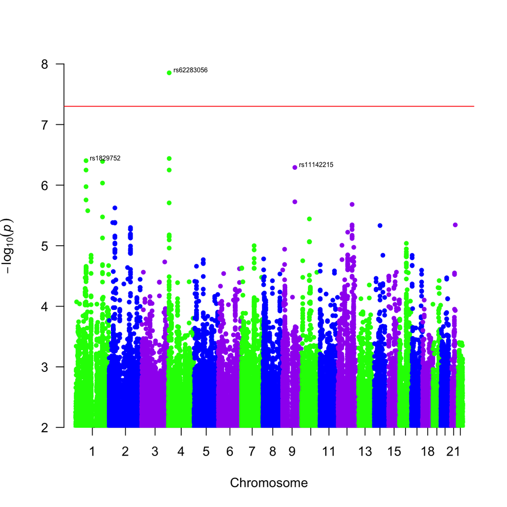

```r
gwas2 <- dplyr::filter(gwasfilt,P<0.01)
#only plot SNPs with P<0.01
manhattan(gwas2,suggestiveline = FALSE, col=c("green", "blue", "purple"), annotatePval = 1e-06,ylim=c(2,8))
```

```r
jpeg(filename= my.dir %&% "plots/rnGM412_age.NEWdose.10PCs.hwe1e-06_manplot.jpeg",width=600,height=360,res=100)
#manhattan(gwas,suggestiveline = FALSE, col=c("green", "blue", "purple"), annotatePval = 1e-06)
manhattan(gwas2,suggestiveline = FALSE, col=c("green", "blue", "purple"),ylim=c(2,8))
dev.off()
```

quartz_off_screen 2

```r
summary(gwas$P)
```

Min. 1st Qu. Median Mean 3rd Qu. Max. 0.0000 0.2413 0.4915 0.4942 0.7462 1.0000

```r
#qqunif(gwas$P,plot=TRUE)
#jpeg(filename= my.dir %&% "plots/rnGM412_age.dose.10PCs_qqplot.jpeg")
#qqunif(gwas$P,plot=TRUE)
#dev.off()
tophits <- dplyr::filter(gwas,P<=1e-06) %>% arrange(P)
tophits
```

Source: local data table [10 x 12]

```
    SNPpos CHR         SNP        BP A1 A2    FRQ   INFO    BETA
```

1 4:6276630 4 rs62283056 6276630 C G 0.2111 0.9683 0.3430 2 1:151774888 1 rs61732470 151774888 T G 0.0125 0.9381 1.2044 3 1:151707930 1 rs139575665 151707930 T C 0.0128 0.8839 1.1678 4 4:6276805 4 rs62283057 6276805 T C 0.1653 0.9579 0.3416 5 1:77447611 1 rs1829752 77447611 A G 0.5469 0.9250 0.2568 6 1:199578450 1 rs10919728 199578450 A T 0.3690 0.9328 0.2643 7 9:90897140 9 rs11142215 90897140 G A 0.1570 0.9511 -0.3419 8 4:6275735 4 rs17718958 6275735 A G 0.1677 0.9687 0.3317 9 1:77453593 1 rs2143582 77453593 T C 0.5499 0.9405 0.2516 10 1:199578296 1 rs10919727 199578296 G A 0.3297 0.8571 0.2745 Variables not shown: SE (dbl), P (dbl), hweP (dbl)

## QQ-plot of all SNPs and SNPs in deafness genes

```r
genes<-read.table(my.dir %&% "deafness_genes/N88.imputed_rnGM412_age.NEWcisp.10PCs_chr1-22.assoc.dosage_combined_deafness_genes_50kb.txt",header=T) %>% arrange(P)
dim(genes)
```

```
## [1] 34095    15
```

```r
nn = length(genes$P)
xx =  -log10((1:nn)/(nn+1))
jpeg(filename= my.dir %&% "plots/rnGM412_age.NEWdose.10PCs.hwe1e-06_qqplot_combined_deafness_genes_50kb.jpeg",res=100)
qqunif(gwasfilt$P,plot=TRUE,BH=F)
points(xx,-log10(genes$P),cex=0.5,pch=19,col='red')
legend('bottomright', c("SNPs in Mendelian\nGenes for Deafness","All SNPs"),col=c('red','black'), pch=19, cex=1)
dev.off()
```

```r
a<-filter(genes,P<0.01)
dim(a)
```

```
## [1] 557  15
```

```r
unique(a$gene)
```

```
##  [1] WFS1     MARVELD2 CLDN14   PCDH15   TJP2     COL11A2  SLC17A8
##  [8] TMEM132E P2RX2    ESRRB    CIB2     MYO3A    SERPINB6 GRXCR2
## [15] KCNQ4    TMC1     BSND     FAM65B   COCH     EYA4     CDH23
## [22] USH1C    OTOG     MYH14    TSPEAR   TNC      ELMOD3   STRC
## [29] MYO7A    MSRB3    HOMER2   GIPC3    GRHL2
## 84 Levels: ACTG1 ADCY1 BDP1 BSND CABP2 CCDC50 CDH23 CEACAM16 ... WFS1
```

```r
a<-filter(genes,P<0.05)
dim(a)
```

```
## [1] 2226   15
```

```r
unique(a$gene)
```

```
##  [1] WFS1     MARVELD2 CLDN14   PCDH15   TJP2     COL11A2  SLC17A8
##  [8] TMEM132E P2RX2    ESRRB    CIB2     MYO3A    SERPINB6 GRXCR2
## [15] KCNQ4    TMC1     BSND     FAM65B   COCH     EYA4     CDH23
## [22] USH1C    OTOG     MYH14    TSPEAR   TNC      ELMOD3   STRC
## [29] MYO7A    MSRB3    HOMER2   GIPC3    GRHL2    GRXCR1   LHFPL5
## [36] CEACAM16 DFNA5    OSBPL2   DCDC2    CLIC5    TMIE     RDX
## [43] PTPRQ    SYNE4    DIAPH1   ADCY1    ACTG1    ESPN     TMPRSS3
## [50] GPSM2    ILDR1    OTOF     TECTA    SLC26A4  MYO6     PNPT1
## [57] GJB2     SLC26A5  EPS8     MYO1A    GJB6     LOXHD1   KARS
## [64] HGF
## 84 Levels: ACTG1 ADCY1 BDP1 BSND CABP2 CCDC50 CDH23 CEACAM16 ... WFS1
```

### top hit rs62283056 is in the first intron of *WFS1* Wolfram syndrome 1 (wolframin):

- This gene encodes a transmembrane protein, which is located primarily in the endoplasmic reticulum and ubiquitously expressed with highest levels in brain, pancreas, heart, and insulinoma beta-cell lines. Mutations in this gene are associated with Wolfram syndrome, also called DIDMOAD (Diabetes Insipidus, Diabetes Mellitus, Optic Atrophy, and Deafness), an autosomal recessive disorder. The disease affects the brain and central nervous system. Mutations in this gene can also cause autosomal dominant deafness 6 (DFNA6), also known as DFNA14 or DFNA38. Alternatively spliced transcript variants have been found for this gene. [provided by RefSeq, Mar 2009]